# Laboratorio de regresión lineal ISLR

Rodrigo Chang

Carné: 19000625

### Cargando librerías

```r
library(MASS)
library(ISLR)
```

# Regresión lineal simple

```r
fix(Boston)
names(Boston)
```

```
 [1] "crim"    "zn"      "indus"   "chas"    "nox"     "rm"      "age"     "dis"     "rad"
[10] "tax"     "ptratio" "black"   "lstat"   "medv"
```

R no encuentra las variables

```r
lm.fit <- lm(medv~lstat)
```

Si referimos el dataset o utilizamos la función *attach* entonces la regresión funciona:

```r
lm.fit <- lm(medv ~ lstat, data=Boston)
lm.fit
```

```
Call:
lm(formula = medv ~ lstat, data = Boston)

Coefficients:
(Intercept)        lstat
      34.55        -0.95
```

```r
attach(Boston)
lm.fit <- lm(medv ~ lstat)
lm.fit
```

```
Call:
lm(formula = medv ~ lstat)

Coefficients:
(Intercept)        lstat
      34.55        -0.95
```

Mostramos un resumen más completo de la regresión:

```r
summary(lm.fit)
```

```
Call:
lm(formula = medv ~ lstat)

Residuals:
    Min      1Q  Median      3Q     Max
-15.168  -3.990  -1.318   2.034  24.500

Coefficients:
            Estimate Std. Error t value Pr(>|t|)
(Intercept) 34.55384    0.56263   61.41   <2e-16 ***
lstat       -0.95005    0.03873  -24.53   <2e-16 ***
---
Signif. codes:  0 ‘***’ 0.001 ‘**’ 0.01 ‘*’ 0.05 ‘.’ 0.1 ‘ ’ 1

Residual standard error: 6.216 on 504 degrees of freedom
Multiple R-squared:  0.5441,    Adjusted R-squared:  0.5432
F-statistic: 601.6 on 1 and 504 DF,  p-value: < 2.2e-16
```

Accedemos a las otras piezas de información en la regresión:

```r
names(lm.fit)
```

```
 [1] "coefficients"  "residuals"     "effects"       "rank"          "fitted.values"
 [6] "assign"        "qr"            "df.residual"   "xlevels"       "call"
[11] "terms"         "model"
```

```r
coef(lm.fit)
```

```
(Intercept)       lstat
 34.5538409  -0.9500494
```

Para obtener un intervalo de confianza para los estimadores, utilizamos el comando confint().

```r
confint(lm.fit)
```

```
                2.5 %     97.5 %
(Intercept) 33.448457 35.6592247
lstat       -1.026148 -0.8739505
```

La función predict() puede ser utilizada para producir intervalos de confianza e intervalos de predicción de *medv* para un valor dado de *lstat*.

```r
predict(lm.fit, data.frame(lstat = c(5,10,15)), interval = "confidence")
```

```
       fit      lwr      upr
1 29.80359 29.00741 30.59978
2 25.05335 24.47413 25.63256
3 20.30310 19.73159 20.87461
```

Para obtener los intervalos de predicción:

```r
predict(lm.fit, data.frame(lstat = c(5,10,15)), interval = "prediction")
```

```
       fit       lwr      upr
1 29.80359 17.565675 42.04151
2 25.05335 12.827626 37.27907
3 20.30310  8.077742 32.52846
```

Vamos a graficar las variables:

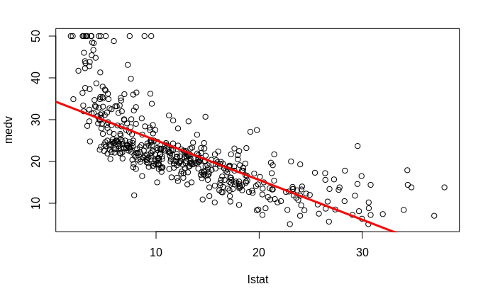

```r
plot(lstat, medv)
abline(lm.fit, lwd = 3, col = "red", pch = "+")
```

Ahora examinamos algunas gráficas de diagnóstico:

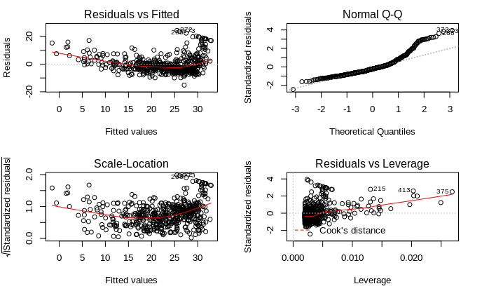

```r
par(mfrow = c(2, 2))
plot(lm.fit)
```

La primera gráfica la podemos producir, de forma alternativa, utilizando los siguientes comandos:

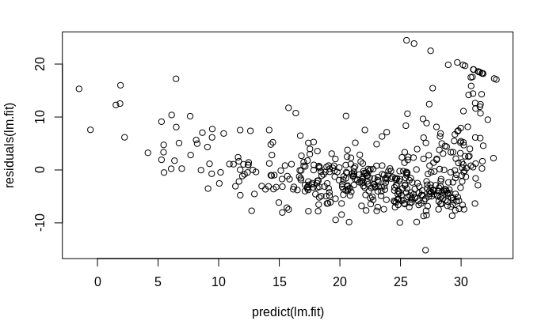

```r
plot(predict(lm.fit), residuals(lm.fit))
```

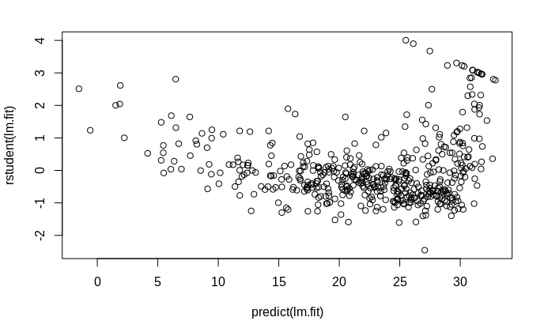

```r
plot(predict(lm.fit), rstudent(lm.fit))
```

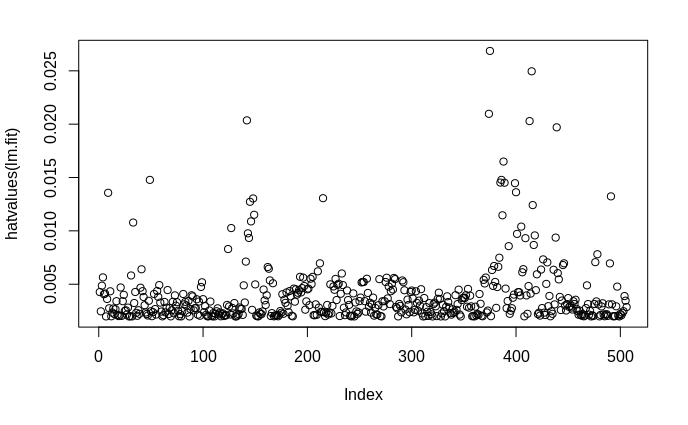

```r
plot(hatvalues(lm.fit))
```

Esta función identifica el índice del elemento más grande de un vector. En este caso, nos muestra la observación con el estadístico de *leverage* más grande.

El *leverage* es una medida de qué tan lejos están los valores de la variable independiente para una observación, del resto de observaciones.

```r
which.max(hatvalues(lm.fit))
```

```
375
375
```

# Regresión lineal múltiple

Utilizando más regresoras:

```r
summary(lm.fit)
```

[output not shown]

```r
lm.fit <- lm(medv ~ . -crim, data = Boston )
summary(lm.fit)
```

```
Call:
lm(formula = medv ~ . - crim, data = Boston)

Residuals:
     Min       1Q   Median       3Q      Max
-15.2714  -2.6792  -0.4958   1.7993  26.6860

Coefficients:
              Estimate Std. Error t value Pr(>|t|)
(Intercept)  3.538e+01  5.143e+00   6.879 1.84e-11 ***
zn           4.249e-02  1.381e-02   3.077 0.002211 **
indus        2.806e-02  6.206e-02   0.452 0.651389
chas         2.828e+00  8.690e-01   3.255 0.001213 **
nox         -1.702e+01  3.851e+00  -4.420 1.22e-05 ***
rm           3.846e+00  4.219e-01   9.116  < 2e-16 ***
age          5.472e-04  1.334e-02   0.041 0.967299
dis         -1.399e+00  2.000e-01  -6.993 8.78e-12 ***
rad          2.478e-01  6.457e-02   3.838 0.000140 ***
tax         -1.219e-02  3.798e-03  -3.210 0.001416 **
ptratio     -9.437e-01  1.321e-01  -7.145 3.26e-12 ***
black        1.035e-02  2.694e-03   3.841 0.000138 ***
lstat       -5.502e-01  5.062e-02 -10.870  < 2e-16 ***
---
Signif. codes:  0 ‘***’ 0.001 ‘**’ 0.01 ‘*’ 0.05 ‘.’ 0.1 ‘ ’ 1

Residual standard error: 4.792 on 493 degrees of freedom
Multiple R-squared:  0.7349,    Adjusted R-squared:  0.7285
F-statistic: 113.9 on 12 and 493 DF,  p-value: < 2.2e-16
```

```r
lm.fit1 <- lm(medv ~ .-age, data = Boston)
summary(lm.fit1)
```

```
Call:
lm(formula = medv ~ . - age, data = Boston)

Residuals:
     Min       1Q   Median       3Q      Max
-15.6054  -2.7313  -0.5188   1.7601  26.2243

Coefficients:
              Estimate Std. Error t value Pr(>|t|)
(Intercept)  36.436927   5.080119   7.172 2.72e-12 ***
crim         -0.108006   0.032832  -3.290 0.001075 **
zn            0.046334   0.013613   3.404 0.000719 ***
indus         0.020562   0.061433   0.335 0.737989
chas          2.689026   0.859598   3.128 0.001863 **
nox         -17.713540   3.679308  -4.814 1.97e-06 ***
rm            3.814394   0.408480   9.338  < 2e-16 ***
dis          -1.478612   0.190611  -7.757 5.03e-14 ***
rad           0.305786   0.066089   4.627 4.75e-06 ***
tax          -0.012329   0.003755  -3.283 0.001099 **
ptratio      -0.952211   0.130294  -7.308 1.10e-12 ***
black         0.009321   0.002678   3.481 0.000544 ***
lstat        -0.523852   0.047625 -10.999  < 2e-16 ***
---
Signif. codes:  0 ‘***’ 0.001 ‘**’ 0.01 ‘*’ 0.05 ‘.’ 0.1 ‘ ’ 1

Residual standard error: 4.74 on 493 degrees of freedom
Multiple R-squared:  0.7406,    Adjusted R-squared:  0.7343
F-statistic: 117.3 on 12 and 493 DF,  p-value: < 2.2e-16
```

Utilizando la función *update*

```r
lm.fit1 <- update(lm.fit, ~.-age)
```

# Términos de interacción

Esta notación incluye las dos variables y su interración (producto)

```r
summary(lm(medv ~ lstat*age, data = Boston))
```

```
Call:
lm(formula = medv ~ lstat * age, data = Boston)

Residuals:
    Min      1Q  Median      3Q     Max
-15.806  -4.045  -1.333   2.085  27.552

Coefficients:
              Estimate Std. Error t value Pr(>|t|)
(Intercept) 36.0885359  1.4698355  24.553  < 2e-16 ***
lstat       -1.3921168  0.1674555  -8.313 8.78e-16 ***
age         -0.0007209  0.0198792  -0.036   0.9711
lstat:age    0.0041560  0.0018518   2.244   0.0252 *
---
Signif. codes:  0 ‘***’ 0.001 ‘**’ 0.01 ‘*’ 0.05 ‘.’ 0.1 ‘ ’ 1

Residual standard error: 6.149 on 502 degrees of freedom
Multiple R-squared:  0.5557,    Adjusted R-squared:  0.5531
F-statistic: 209.3 on 3 and 502 DF,  p-value: < 2.2e-16
```

# Transformaciones no lineales de las variables predictoras

Haciendo una regresión de *medv* con *lstat* y *lstat*^2

```r
summary(lm.fit2)
```

[output not shown]

El p-valor cercano a cero del término cuadrático sugiere que el modelo cuadrático es mejor al modelo lineal. Utilizamos la función anova() para cuantificar en qué grado el ajuste del modelo cuadrático es mejor al del modelo lineal:

```r
lm.fit <- lm(medv ~ lstat, data = Boston)
anova (lm.fit, lm.fit2)
```

```
Analysis of Variance Table

Model 1: medv ~ lstat
Model 2: medv ~ lstat + I(lstat^2)
  Res.Df   RSS Df Sum of Sq     F    Pr(>F)
1    504 19472
2    503 15347  1    4125.1 135.2 < 2.2e-16 ***
---
Signif. codes:  0 ‘***’ 0.001 ‘**’ 0.01 ‘*’ 0.05 ‘.’ 0.1 ‘ ’ 1
```

La hipótesis nula es que ambos modelos ajustan los datos igualmente bien. La hipótesis alternativa es que el modelo completo (con término cuadrático) es superior. En este caso, existe evidencia clara para aseverar que el modelo con término cuadrático es muy superior al modelo lineal simple. Esto no es sorpresa del todo, debido a que anteriormente vimos que existía una relación no lineal entre las variables *medv* y *lstat*.

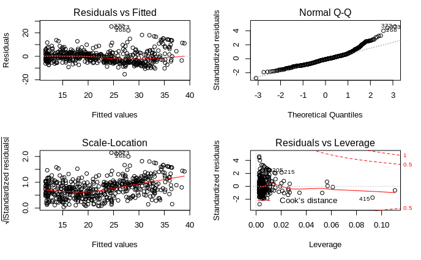

```r
par(mfrow = c(2,2))
plot(lm.fit2)
```

Para crear un polinomio de mayor grado, podemos utilizar la función *poly()*:

```r
lm.fit5 <- lm(medv ~ poly(lstat, 5), data = Boston)
summary(lm.fit5)
```

```
Call:
lm(formula = medv ~ poly(lstat, 5), data = Boston)

Residuals:
     Min       1Q   Median       3Q      Max
-13.5433  -3.1039  -0.7052   2.0844  27.1153

Coefficients:
                 Estimate Std. Error t value Pr(>|t|)
(Intercept)       22.5328     0.2318  97.197  < 2e-16 ***
poly(lstat, 5)1 -152.4595     5.2148 -29.236  < 2e-16 ***
poly(lstat, 5)2   64.2272     5.2148  12.316  < 2e-16 ***
poly(lstat, 5)3  -27.0511     5.2148  -5.187 3.10e-07 ***
poly(lstat, 5)4   25.4517     5.2148   4.881 1.42e-06 ***
poly(lstat, 5)5  -19.2524     5.2148  -3.692 0.000247 ***
---
Signif. codes:  0 ‘***’ 0.001 ‘**’ 0.01 ‘*’ 0.05 ‘.’ 0.1 ‘ ’ 1

Residual standard error: 5.215 on 500 degrees of freedom
Multiple R-squared:  0.6817,    Adjusted R-squared:  0.6785
F-statistic: 214.2 on 5 and 500 DF,  p-value: < 2.2e-16
```

También es posible utilizar otras transformaciones de las variables predictoras.

```r
summary(lm(medv~log(rm), data = Boston))
```

```
Call:
lm(formula = medv ~ log(rm), data = Boston)

Residuals:
    Min      1Q  Median      3Q     Max
-19.487  -2.875  -0.104   2.837  39.816

Coefficients:
            Estimate Std. Error t value Pr(>|t|)
(Intercept)  -76.488      5.028  -15.21   <2e-16 ***
log(rm)       54.055      2.739   19.73   <2e-16 ***
---
Signif. codes:  0 ‘***’ 0.001 ‘**’ 0.01 ‘*’ 0.05 ‘.’ 0.1 ‘ ’ 1

Residual standard error: 6.915 on 504 degrees of freedom
Multiple R-squared:  0.4358,    Adjusted R-squared:  0.4347
F-statistic: 389.3 on 1 and 504 DF,  p-value: < 2.2e-16
```

# Variables predictoras cualitativas (dicótomas o *dummies*)

```r
fix(Carseats)
names(Carseats)
```

```
 [1] "Sales"       "CompPrice"   "Income"      "Advertising" "Population"  "Price"
 [7] "ShelveLoc"   "Age"         "Education"   "Urban"       "US"
```

La variable “ShelveLoc” es cualtiativa, con valores *Bad*, *Medium* y *Good*. Cuando la variable es un factor, R crea automáticamente variables *dummy* para la regresión.

```r
str(Carseats$ShelveLoc)
```

```
 Factor w/ 3 levels "Bad","Good","Medium": 1 2 3 3 1 1 3 2 3 3 ...
```

```r
lm.fit <- lm(Sales ~ . + Income:Advertising + Price:Age, data=Carseats)
summary(lm.fit)
```

```
Call:
lm(formula = Sales ~ . + Income:Advertising + Price:Age, data = Carseats)

Residuals:
    Min      1Q  Median      3Q     Max
-2.9208 -0.7503  0.0177  0.6754  3.3413

Coefficients:
                     Estimate Std. Error t value Pr(>|t|)
(Intercept)         6.5755654  1.0087470   6.519 2.22e-10 ***
CompPrice           0.0929371  0.0041183  22.567  < 2e-16 ***
Income              0.0108940  0.0026044   4.183 3.57e-05 ***
Advertising         0.0702462  0.0226091   3.107 0.002030 **
Population          0.0001592  0.0003679   0.433 0.665330
Price              -0.1008064  0.0074399 -13.549  < 2e-16 ***
ShelveLocGood       4.8486762  0.1528378  31.724  < 2e-16 ***
ShelveLocMedium     1.9532620  0.1257682  15.531  < 2e-16 ***
Age                -0.0579466  0.0159506  -3.633 0.000318 ***
Education          -0.0208525  0.0196131  -1.063 0.288361
UrbanYes            0.1401597  0.1124019   1.247 0.213171
USYes              -0.1575571  0.1489234  -1.058 0.290729
Income:Advertising  0.0007510  0.0002784   2.698 0.007290 **
Price:Age           0.0001068  0.0001333   0.801 0.423812
---
Signif. codes:  0 ‘***’ 0.001 ‘**’ 0.01 ‘*’ 0.05 ‘.’ 0.1 ‘ ’ 1

Residual standard error: 1.011 on 386 degrees of freedom
Multiple R-squared:  0.8761,    Adjusted R-squared:  0.8719
F-statistic:   210 on 13 and 386 DF,  p-value: < 2.2e-16
```

La función *contrasts()* devuelve la codificación utilizada por R para la variable dicótoma:

```r
attach(Carseats)
contrasts(ShelveLoc)
```

```
       Good Medium
Bad       0      0
Good      1      0
Medium    0      1
```

Esto quiere decir que la categoría base en la regresión es el valor ShelveLocGood = 0 y ShelveLocMedium = 0, es decir, la categoría base es cuando ShelveLoc = “Bad”.

# Escribiendo funciones

Vamos a crear una función que cargue las librerías:

```r
LoadLibraries = function () {
  library(ISLR)
  library(MASS)
  print("Las librerías fueron cargadas.")
}
```

Si escribimos el nombre de nuestra función, R nos devuelve su código:

```r
LoadLibraries
```

```
function () {
  library(ISLR)
  library(MASS)
  print("Las librerías fueron cargadas.")
}
```

Para llamarla, utilizamos los paréntesis:

```r
LoadLibraries()
```

```
[1] "Las librerías fueron cargadas."
```